# **Panorama da inflação**

Os principais índices de inflação do Brasil, apontam em junho de 2003 um recuo da inflação de em média **-0.40%**. Com esse resultado, no ano a inflação acumula uma variação média positiva de **5.99%**, e em 12 meses uma variação média acumulada de **21.48%**.

[output not shown]

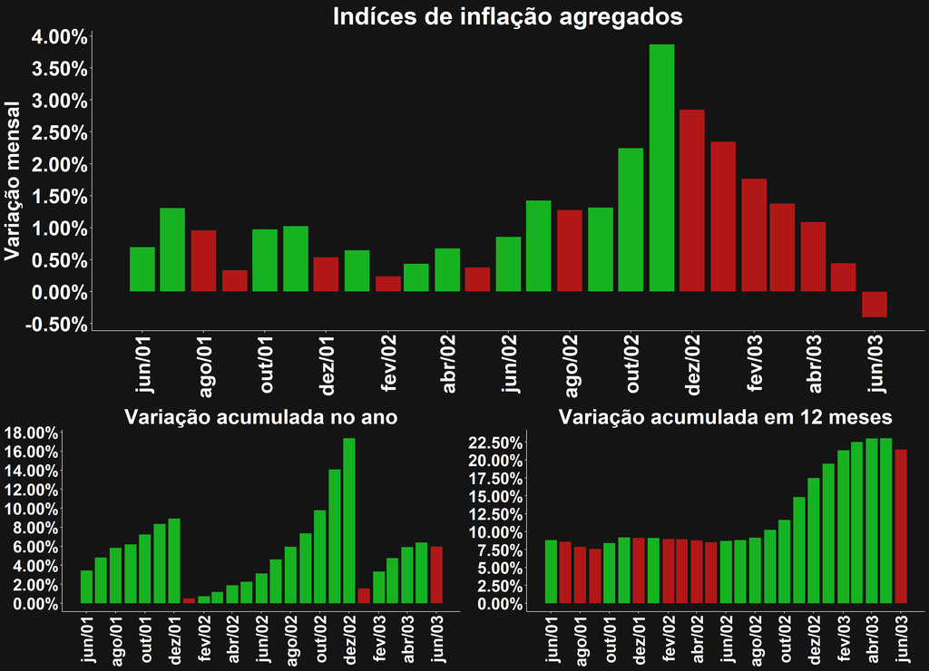

Índices selecionados para a média: IPCA, INPC e IGP-M.

# IPCA

O Indíce de Preços ao Consumidor Amplo (IPCA) variou -0.15% em junho, valor inferior ao mesmo período do ano anterior quando apresentou uma taxa de 0.42%. Com esse resultado o indíce acumula no ano uma variação positiva de 6.64%, e em 12 meses uma variação positiva de 16.57%.

|  | 06/2002 | 05/2003 | 06/2003 |
| --- | --- | --- | --- |
| Variação mensal | 0.42% | 0.61% | -0.15% |
| Variação acumulada no ano | 2.94% | 6.8% | 6.64% |
| Variação acumulada em 12 meses | 7.66% | 17.24% | 16.57% |

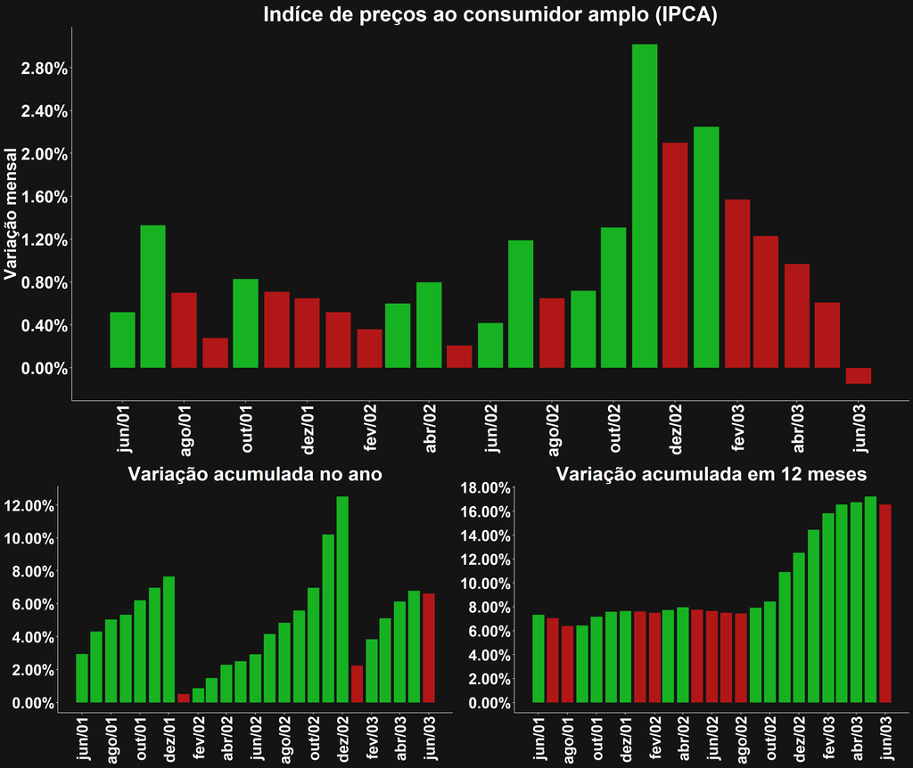

Os grupos que tiveram maior resultado positivo foram Vestuário (1.89%) e Habitação (0.52%), e negativo Transportes (-1.45%) e Alimentação e bebidas (-0.34%).

|  | Variação mensal | Variação acumulada no ano | Peso mensal |
| --- | --- | --- | --- |
| Alimentação e bebidas | -0.34% | 6.48% | 23.77% |
| Habitação | 0.52% | 8.01% | 16.22% |
| Artigos de residência | -0.03% | 5.86% | 5.68% |
| Vestuário | 1.89% | 5.84% | 5.05% |
| Transportes | -1.45% | 6.7% | 21.89% |
| Saúde e cuidados pessoais | 0.34% | 7.29% | 10.42% |
| Despesas pessoais | 0.22% | 4.04% | 8.88% |
| Educação | 0.12% | 8.76% | 4.68% |
| Comunicação | 0.19% | 5.59% | 3.4% |

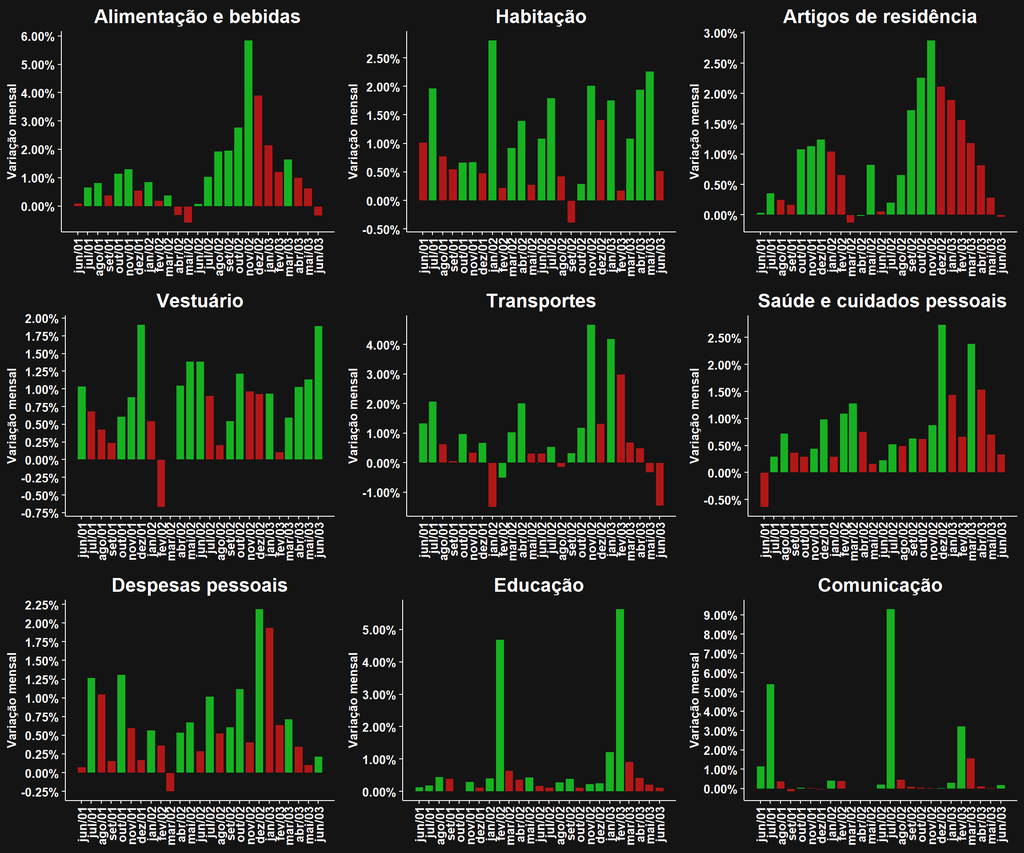

A nível de sub-itens os que mais influenciaram positivamente no resultado em relação ao seu peso foram Arroz (6.2%%) e Condomínio (3.06%%), e negativamente Gasolina (-4.94%%) e Etanol (-12.14%%).

|  | Variação mensal | Variação acumulada no ano | Peso mensal |
| --- | --- | --- | --- |
| Arroz | 6.2% | 20.78% | 1.02% |
| Condomínio | 3.06% | 7.17% | 1.71% |
| Ônibus intermunicipal | 1.98% | 15.43% | 1.08% |
| Leite pasteurizado | 1.93% | 10.11% | 1.36% |

|  | Variação mensal | Variação acumulada no ano | Peso mensal |
| --- | --- | --- | --- |
| Açúcar cristal | -10.95% | -5.36% | 0.25% |
| Etanol | -12.14% | 0.53% | 1.26% |
| Tomate | -25.02% | 17.92% | 0.14% |
| Gasolina | -4.94% | 2.1% | 4.4% |

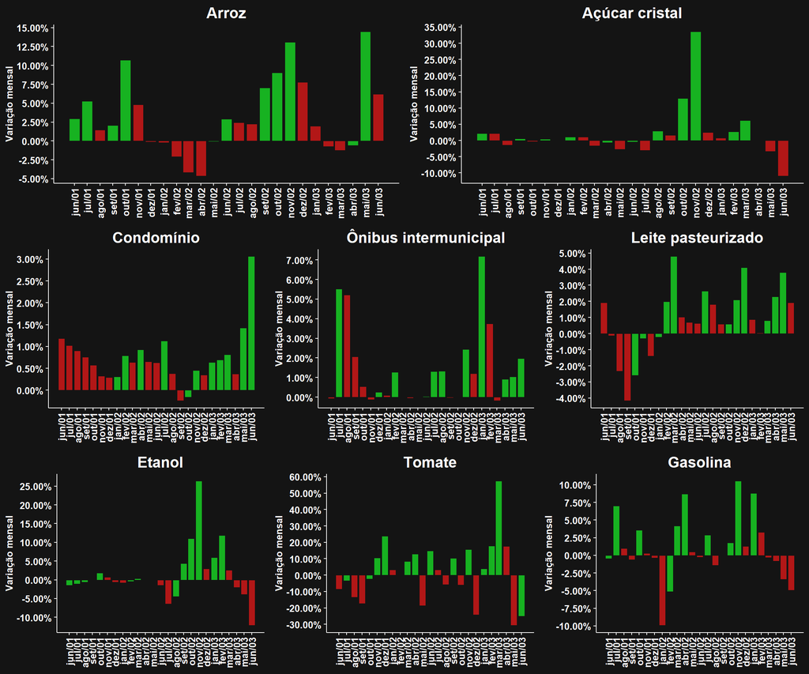

# INPC

O Indíce Nacional de Preços ao Consumidor (INPC) variou -0.06% em junho, valor inferior ao mesmo período do ano anterior quando apresentou uma taxa de 0.61%. Com esse resultado o indíce acumula no ano uma variação positiva de 7.84%, e em 12 meses uma variação positiva de 19.64%.

|  | 06/2002 | 05/2003 | 06/2003 |
| --- | --- | --- | --- |
| Variação mensal | 0.61% | 0.99% | -0.06% |
| Variação acumulada no ano | 3.42% | 7.9% | 7.84% |
| Variação acumulada em 12 meses | 9.04% | 20.44% | 19.64% |

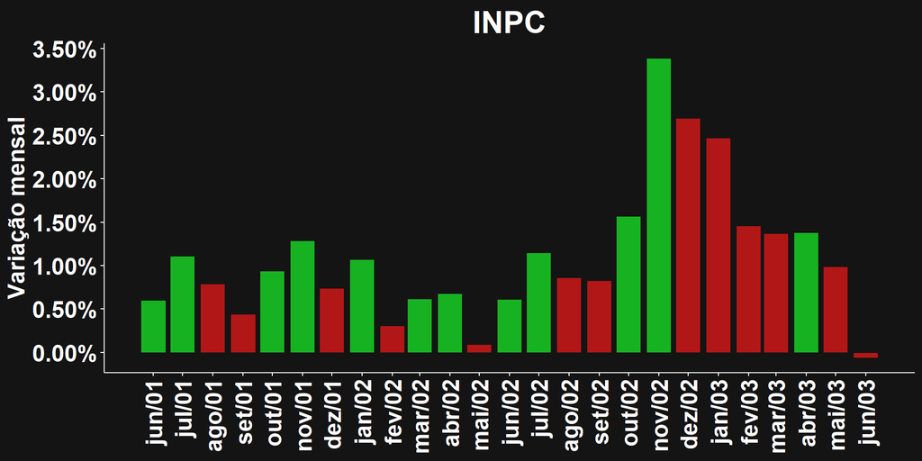

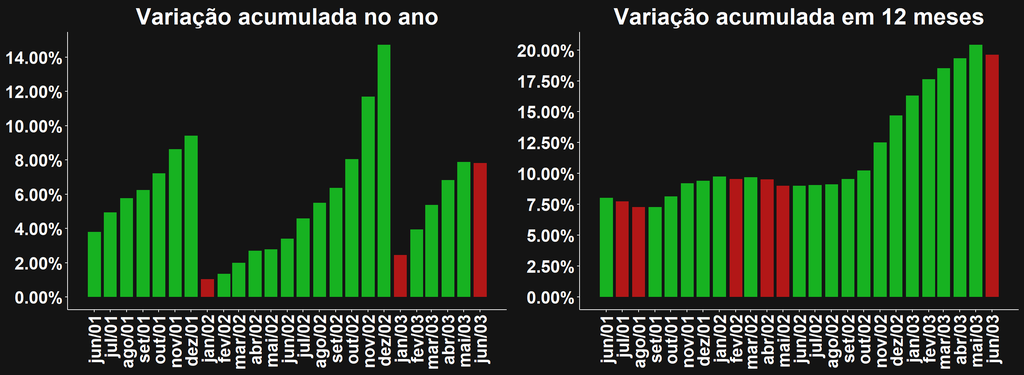

# IGP-M

O Indíce Geral de Preços de Mercado (IGP-M) variou -1% em junho, valor inferior ao mesmo período do ano anterior quando apresentou uma taxa de 1.54%. Com esse resultado o indíce acumula no ano uma variação positiva de 3.49%, e em 12 meses uma variação positiva de 28.23%.

|  | 06/2002 | 05/2003 | 06/2003 |
| --- | --- | --- | --- |
| Variação mensal | 1.54% | -0.26% | -1% |
| Variação acumulada no ano | 3.11% | 4.54% | 3.49% |
| Variação acumulada em 12 meses | 9.48% | 31.53% | 28.23% |

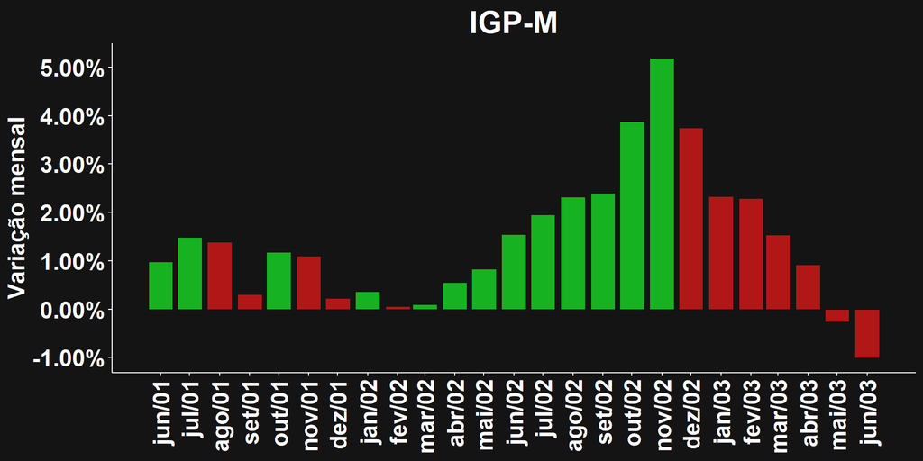

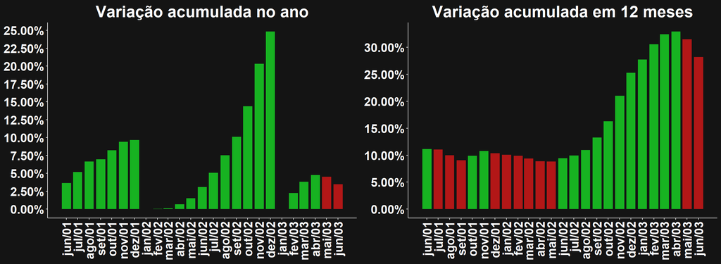

# IGP-DI

O Indíce Geral de Preços - Disponibilidade Interna (IGP-DI) variou -0.7% em junho, valor inferior ao mesmo período do ano anterior quando apresentou uma taxa de 1.74%. Com esse resultado o indíce acumula no ano uma variação positiva de 2.29%, e em 12 meses uma variação positiva de 26.94%.

|  | 06/2002 | 05/2003 | 06/2003 |
| --- | --- | --- | --- |
| Variação mensal | 1.74% | -0.67% | -0.7% |
| Variação acumulada no ano | 3.89% | 3.01% | 2.29% |
| Variação acumulada em 12 meses | 9.7% | 30.05% | 26.94% |

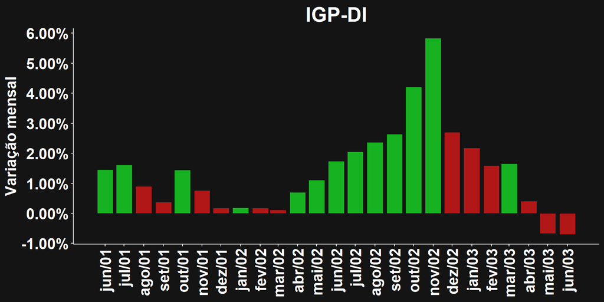

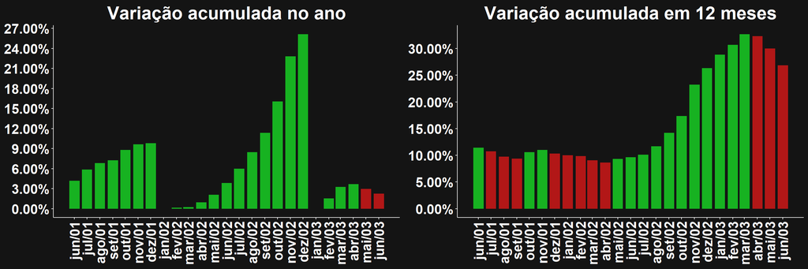

[output not shown]

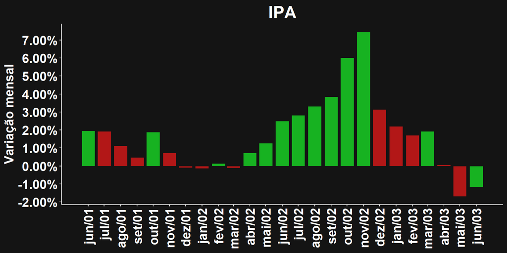

[figure not shown]

O Indíce de Preços ao Consumidor (IPC), integrante do IGP-DI com peso de 30%, apresentou variação de -0.16% em junho, valor inferior ao mesmo período do ano anterior quando apresentou uma taxa de 0.55%. Com esse resultado o indíce acumula no ano uma variação positiva de 4.14%, e em 12 meses uma variação positiva de 16.12%.

|  | 06/2002 | 05/2003 | 06/2003 |
| --- | --- | --- | --- |
| Variação mensal | 0.55% | 0.69% | -0.16% |
| Variação acumulada no ano | 2.12% | 4.3% | 4.14% |
| Variação acumulada em 12 meses | 7.42% | 16.95% | 16.12% |

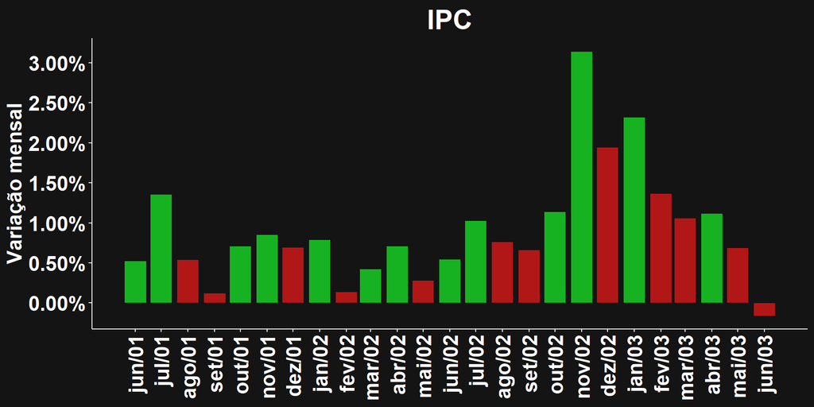

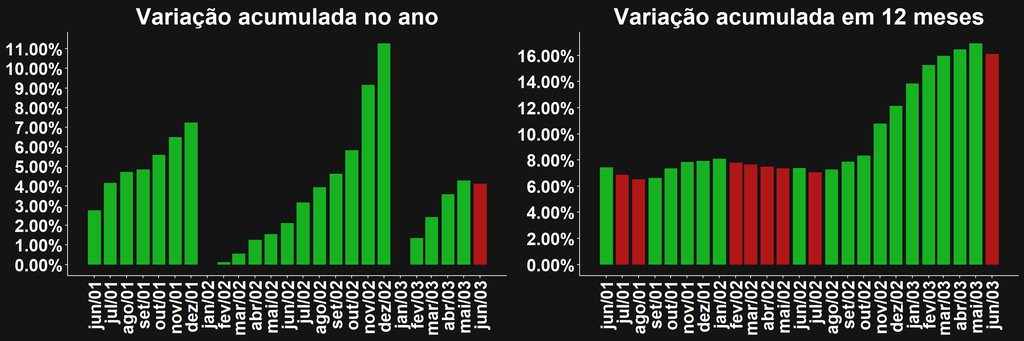

O Indíce Nacional de Custos de Construção (INCC), integrante do IGP-DI com peso de 10%, apresentou variação de 1.05% em junho, valor superior ao mesmo período do ano anterior quando apresentou uma taxa de 0.57%. Com esse resultado o indíce acumula no ano uma variação positiva de 7.78%, e em 12 meses uma variação positiva de 17.61%.

|  | 06/2002 | 05/2003 | 06/2003 |
| --- | --- | --- | --- |
| Variação mensal | 0.57% | 2.84% | 1.05% |
| Variação acumulada no ano | 4.62% | 6.66% | 7.78% |
| Variação acumulada em 12 meses | 8.93% | 17.05% | 17.61% |

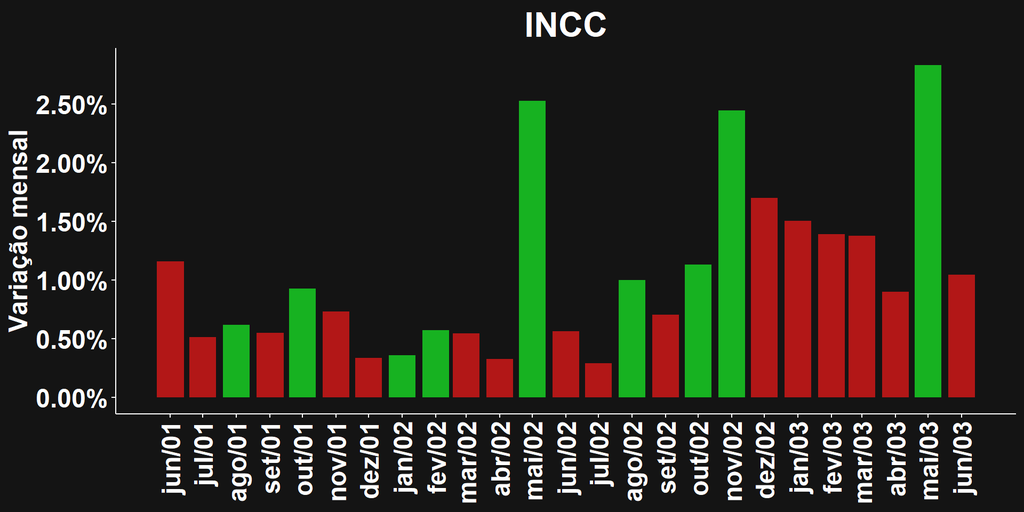

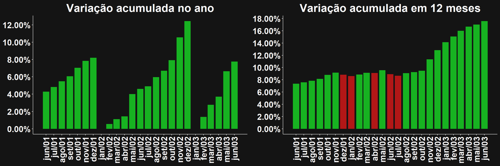

# Estatísticas

As estatísticas descritivas a seguir são feitas com base nos últimos 48 meses, e tem como objetivo possibilitar a avaliação do resultado observado em comparação aos períodos anteriores.

|  | Minimo | 1 Quartil | Mediana | Media | 3 Quartil | Maximo | Desvio Padrão |
| --- | --- | --- | --- | --- | --- | --- | --- |
| IPCA | -0.15% | 0.38% | 0.6% | 0.76% | 1% | 3.02% | 0.61% |
| INPC | -0.06% | 0.44% | 0.74% | 0.83% | 1.08% | 3.39% | 0.68% |
| IGP-M | -1% | 0.36% | 1.05% | 1.22% | 1.61% | 5.19% | 1.12% |
| IGP-DI | -0.7% | 0.39% | 0.97% | 1.2% | 1.68% | 5.84% | 1.16% |
| IPA | -1.68% | 0.36% | 1.2% | 1.48% | 2.23% | 7.45% | 1.64% |
| IPC | -0.16% | 0.4% | 0.65% | 0.75% | 1.02% | 3.14% | 0.62% |
| INCC | 0.26% | 0.45% | 0.7% | 0.88% | 1.06% | 2.84% | 0.61% |

Levando em consideração o desvio padrão de cada indíce, proporcionalmente os que mais se afastaram da média foram o IGP-M, o IGP-DI e o IPA.

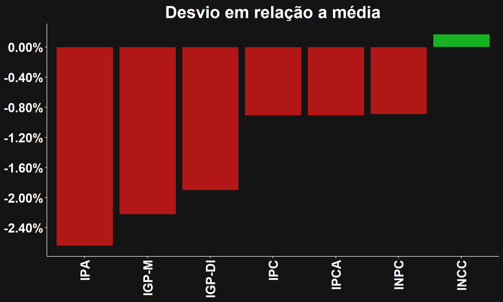

**João Victor Gomes**  
**jvg.santana@gmail.com**  
**[linkedin.com/in/jvictorgomes](https://www.linkedin.com/in/jvictorgomes/)**